# Determinants of Economic Growth

Sanskriti Giri, Adiba Mobarak, Autumn Larsen

2023-04-29

```r
dj = read.csv("GrowthDJ.csv")
```

#### Percentage of NA values

```r
df1 = data.frame(dj)
(colMeans(is.na(df1)))*100
```

```
##          X        oil      inter       oecd      gdp60      gdp85  gdpgrowth
##   0.000000   0.000000   0.000000   0.000000   4.132231  10.743802   3.305785
##  popgrowth     invest     school literacy60
##  11.570248   0.000000   2.479339  14.876033
```

#### Imputing the data

```r
library(mice)
my_imputation = mice(dj,m=5,maxit=100,method="mean")
imputed_data = complete(my_imputation)
dj = data.frame(imputed_data)
head(dj)
```

```
##   X oil inter oecd gdp60 gdp85 gdpgrowth popgrowth invest school literacy60
## 1 1  no   yes   no  2485  4371       4.8       2.6   24.1    4.5   10.00000
## 2 2  no    no   no  1588  1171       0.8       2.1    5.8    1.8    5.00000
## 3 3  no    no   no  1116  1071       2.2       2.4   10.8    1.8    5.00000
## 4 4  no   yes   no   959  3671       8.6       3.2   28.3    2.9   48.16505
## 5 5  no    no   no   529   857       2.9       0.9   12.7    0.4    2.00000
## 6 6  no    no   no   755   663       1.2       1.7    5.1    0.4   14.00000
```

#### Variable descriptions

```r
table(dj$oil)
```

```
##
##  no yes
##  98  23
```

The variable $oil$ is a binary variable that indicates whether a given country is oil-producing ($yes$) or not ($no$). In this data, 98 countries are not oil-producing and 23 are.

```r
table(dj$inter)
```

```
##
##  no yes
##  46  75
```

The variable $inter$ is a binary variable that indicates whether a given country has better quality data ($yes$) or not ($no$). In this data, 46 countries do not have better quality data and 75 do.

```r
table(dj$oecd)
```

```
##
##  no yes
##  99  22
```

The variable $oecd$ is a binary variable that indicates whether a given country is a member of the OECD (Organisation for Economic Co-operation and Development) ($yes$) or not ($no$). In this data, 99 countries are not members, and 22 are.

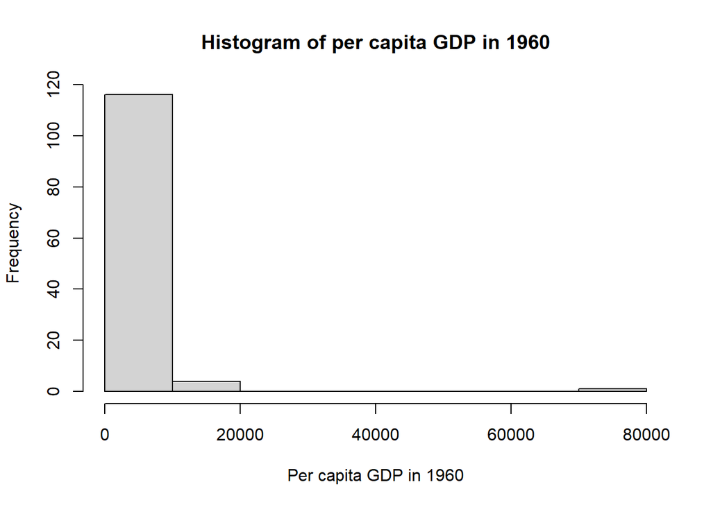

```r
hist(dj$gdp60, main="Histogram of per capita GDP in 1960", xlab = "Per capita GDP in 1960")
```

The variable $gdp60$ is a continuous variable indicating the per capita GDP (gross domestic product) of a given country in the year 1960. The data is skewed to the right, with an outlier between 70,000 and 80,000.

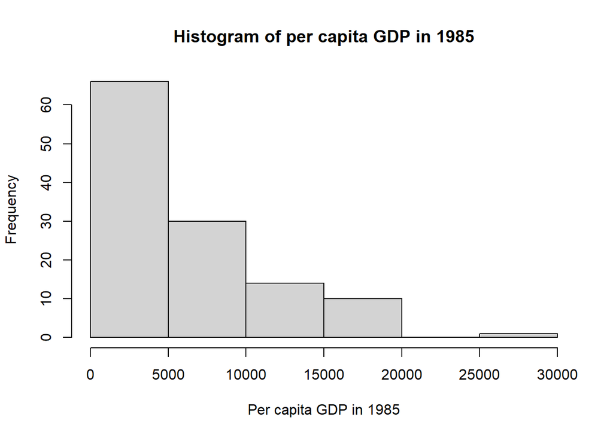

```r
hist(dj$gdp85, main="Histogram of per capita GDP in 1985", xlab = "Per capita GDP in 1985")
```

The variable $gdp1985$ is a continuous variable indicating the per capita GDP of a given country in the year 1985. The data is skewed right with an outlier between 25,000 and 30,000.

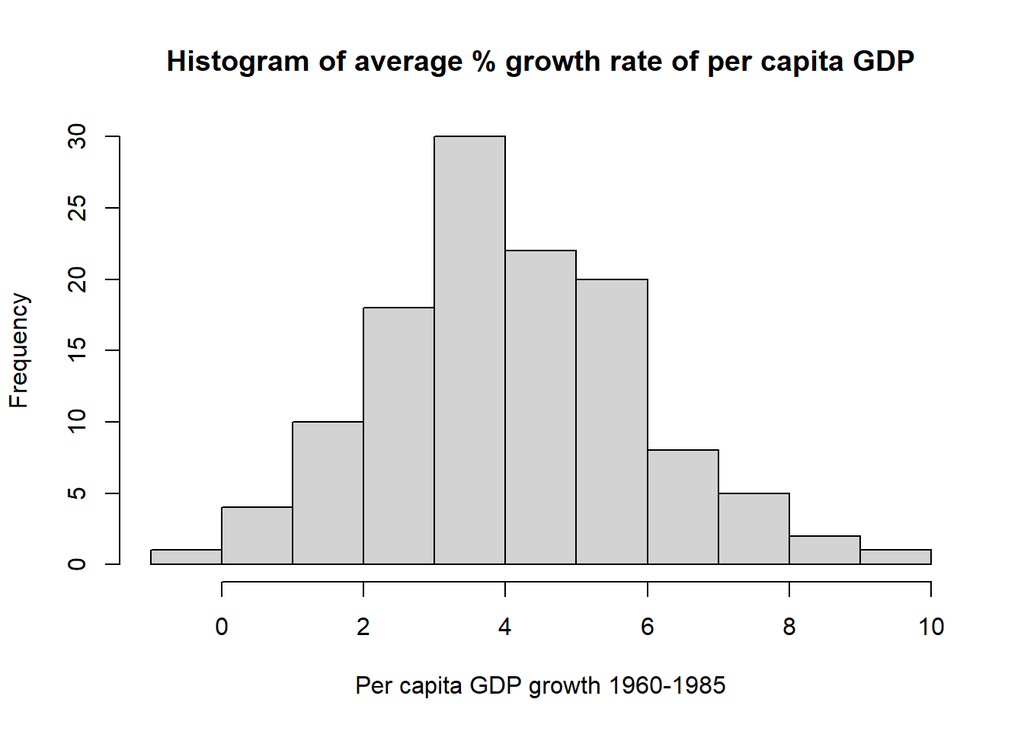

```r
hist(dj$gdpgrowth, main="Histogram of average % growth rate of per capita GDP", xlab = "Per capita GDP growth 1960-1985")
```

The variable $gdpgrowth$ is a continuous variable indicating the average growth rate of per capita GDP of a given country from 1960 to 1985 as a percentage. This data is mostly normally distributed with a slight right skew.

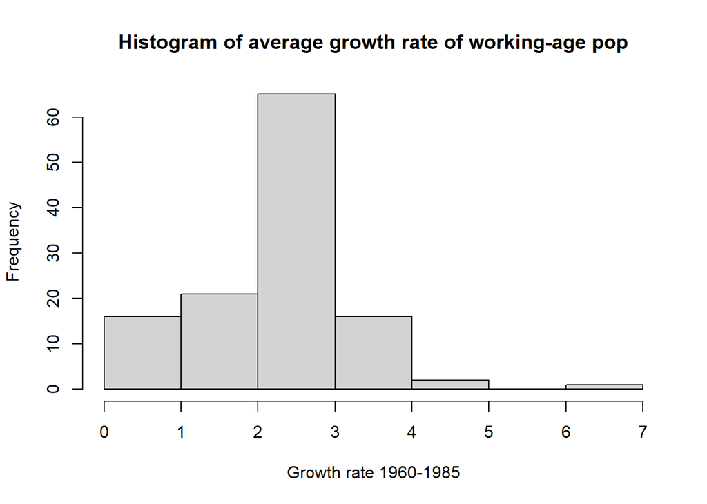

```r
hist(dj$popgrowth, main="Histogram of average growth rate of working-age pop", xlab = "Growth rate 1960-1985")
```

The variable $popgrowth$ is a continuous variable indicating the average growth rate of working-age population from 1960 to 1985 of a given country as a percentage. This data is somewhat normally distributed with a right skew and an outlier between 6 and 7.

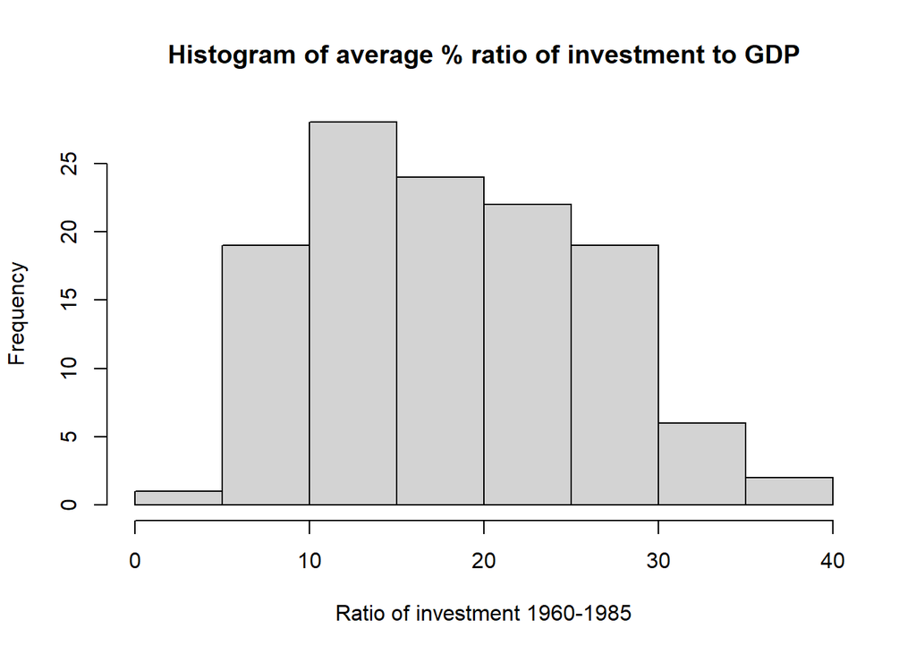

```r
hist(dj$invest, main="Histogram of average % ratio of investment to GDP", xlab = "Ratio of investment 1960-1985")
```

The variable $invest$ is a continuous variable indicating the average ratio of investment (including Government Investment) to GDP of a given country from 1960 to 1985 as a percentage. This data seems normally distributed.

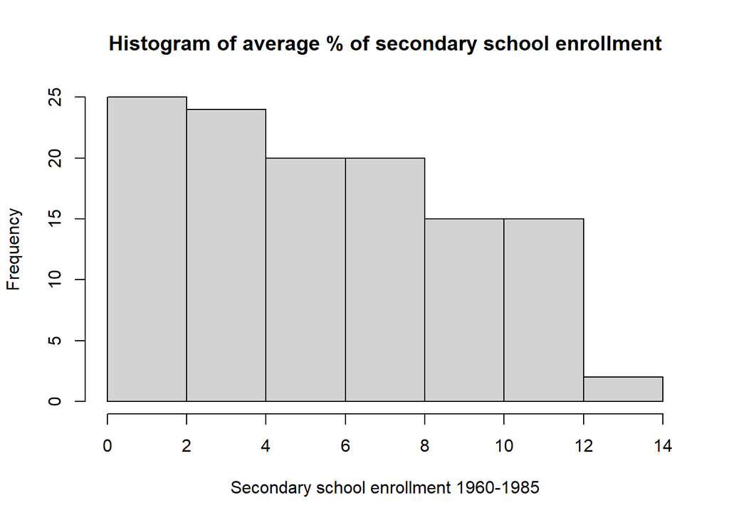

```r
hist(dj$school, main="Histogram of average % of secondary school enrollment", xlab = "Secondary school enrollment 1960-1985")
```

The variable $school$ is a continuous variable indicating the average fraction of working-age population enrolled in secondary school of a given country from 1960 to 1985 as a percentage. This data is skewed right.

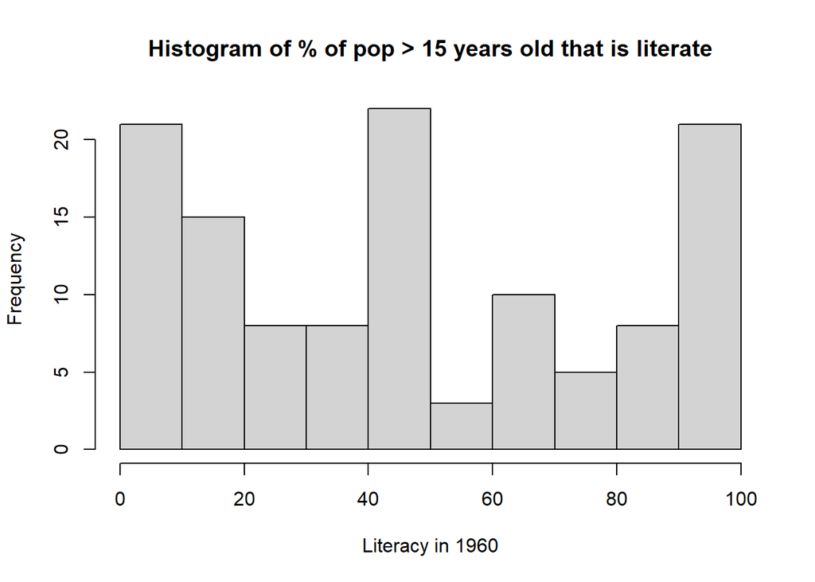

```r
hist(dj$literacy60, main="Histogram of % of pop > 15 years old that is literate", xlab = "Literacy in 1960")
```

The variable $literacy60$ is a continuous variable indicating the fraction of the population of a given country over 15 years old that is able to read and write in 1960 as a percentage. This data is not normally distributed.

#### Variable selection

```r
dj$oil=ifelse(dj$oil=="yes",1,0)
dj$inter=ifelse(dj$inter=="yes",1,0)
dj$oecd=ifelse(dj$oecd=="yes",1,0)

library(olsrr)
dj1=dj[,-c(1,5,6)]
head(dj1)
```

```
##   oil inter oecd gdpgrowth popgrowth invest school literacy60
## 1   0     1    0       4.8       2.6   24.1    4.5   10.00000
## 2   0     0    0       0.8       2.1    5.8    1.8    5.00000
## 3   0     0    0       2.2       2.4   10.8    1.8    5.00000
## 4   0     1    0       8.6       3.2   28.3    2.9   48.16505
## 5   0     0    0       2.9       0.9   12.7    0.4    2.00000
## 6   0     0    0       1.2       1.7    5.1    0.4   14.00000
```

```r
model1=lm(gdpgrowth~.,data = dj1)
ols_step_forward_p(model1,details= FALSE)
```

```
##
##                             Selection Summary
## --------------------------------------------------------------------------
##         Variable                   Adj.
## Step     Entered     R-Square    R-Square     C(p)        AIC        RMSE
## --------------------------------------------------------------------------
##    1    invest         0.1192      0.1118    26.0577    483.1566    1.7526
##    2    popgrowth      0.2412      0.2283     8.2482    467.1218    1.6336
##    3    inter          0.2699      0.2512     5.5773    464.4470    1.6092
##    4    oil            0.2875      0.2630     4.7167    463.4921    1.5965
##    5    school         0.2987      0.2682     4.9035    463.5811    1.5908
## --------------------------------------------------------------------------
```

#### Model 2

```r
model2=lm(gdpgrowth~invest+popgrowth+inter+oil+school,data = dj1)
summary(model2)
```

```
##
## Call:
## lm(formula = gdpgrowth ~ invest + popgrowth + inter + oil + school,
##     data = dj1)
##
## Residuals:
##     Min      1Q  Median      3Q     Max
## -4.2573 -0.8695 -0.1617  1.0495  3.9439
##
## Coefficients:
##              Estimate Std. Error t value Pr(>|t|)
## (Intercept)  0.006712   0.627161   0.011  0.99148
## invest       0.105505   0.024655   4.279 3.90e-05 ***
## popgrowth    0.694776   0.167186   4.156 6.26e-05 ***
## inter        1.312460   0.430700   3.047  0.00286 **
## oil          1.021982   0.520695   1.963  0.05209 .
## school      -0.075969   0.056148  -1.353  0.17870
## ---
## Signif. codes:  0 '***' 0.001 '**' 0.01 '*' 0.05 '.' 0.1 ' ' 1
##
## Residual standard error: 1.591 on 115 degrees of freedom
## Multiple R-squared:  0.2987, Adjusted R-squared:  0.2682
## F-statistic: 9.797 on 5 and 115 DF,  p-value: 8.086e-08
```

#### Model 3

```r
model3=lm(gdpgrowth~invest+popgrowth+inter+oil+school+oil*popgrowth+I(invest^2),data = dj1)
summary(model3)
```

```
##
## Call:
## lm(formula = gdpgrowth ~ invest + popgrowth + inter + oil + school +
##     oil * popgrowth + I(invest^2), data = dj1)
##
## Residuals:
##     Min      1Q  Median      3Q     Max
## -3.6169 -0.9111 -0.2544  1.1905  3.9596
##
## Coefficients:
##                Estimate Std. Error t value Pr(>|t|)
## (Intercept)   -2.078658   0.839059  -2.477 0.014715 *
## invest         0.332527   0.088307   3.766 0.000265 ***
## popgrowth      0.872157   0.184509   4.727 6.62e-06 ***
## inter          1.070480   0.414307   2.584 0.011047 *
## oil            2.950897   1.011271   2.918 0.004251 **
## school        -0.052702   0.055035  -0.958 0.340304
## I(invest^2)   -0.006030   0.002188  -2.756 0.006816 **
## popgrowth:oil -0.864522   0.355696  -2.431 0.016651 *
## ---
## Signif. codes:  0 '***' 0.001 '**' 0.01 '*' 0.05 '.' 0.1 ' ' 1
##
## Residual standard error: 1.508 on 113 degrees of freedom
## Multiple R-squared:  0.3804, Adjusted R-squared:  0.3421
## F-statistic: 9.913 on 7 and 113 DF,  p-value: 1.336e-09
```

```r
model4=lm(gdpgrowth~invest+popgrowth+inter+oil+school+oil*popgrowth+invest*oil+I(invest^2)+I(school^2),data = dj1)
summary(model4)
```

```
##
## Call:
## lm(formula = gdpgrowth ~ invest + popgrowth + inter + oil + school +
##     oil * popgrowth + invest * oil + I(invest^2) + I(school^2),
##     data = dj1)
##
## Residuals:
##     Min      1Q  Median      3Q     Max
## -3.7520 -0.8604 -0.2166  1.1490  3.5467
##
## Coefficients:
##                Estimate Std. Error t value Pr(>|t|)
## (Intercept)   -2.251727   0.833844  -2.700  0.00801 **
## invest         0.281801   0.091536   3.079  0.00262 **
## popgrowth      0.910408   0.185990   4.895 3.36e-06 ***
## inter          0.803053   0.429493   1.870  0.06415 .
## oil            5.165716   1.703960   3.032  0.00303 **
## school         0.207967   0.181566   1.145  0.25450
## I(invest^2)   -0.004455   0.002293  -1.943  0.05456 .
## I(school^2)   -0.019654   0.013742  -1.430  0.15545
## popgrowth:oil -1.128625   0.384021  -2.939  0.00401 **
## invest:oil    -0.087419   0.052825  -1.655  0.10077
## ---
## Signif. codes:  0 '***' 0.001 '**' 0.01 '*' 0.05 '.' 0.1 ' ' 1
##
## Residual standard error: 1.491 on 111 degrees of freedom
## Multiple R-squared:  0.4051, Adjusted R-squared:  0.3568
## F-statistic: 8.397 on 9 and 111 DF,  p-value: 1.777e-09
```

#### Partial F test models 2 & 3

```r
anova(model2,model3)
```

```
## Analysis of Variance Table
##
## Model 1: gdpgrowth ~ invest + popgrowth + inter + oil + school
## Model 2: gdpgrowth ~ invest + popgrowth + inter + oil + school + oil *
##     popgrowth + I(invest^2)
##   Res.Df    RSS Df Sum of Sq      F    Pr(>F)
## 1    115 291.04
## 2    113 257.12  2    33.921 7.4539 0.0009104 ***
## ---
## Signif. codes:  0 '***' 0.001 '**' 0.01 '*' 0.05 '.' 0.1 ' ' 1
```

#### Partial F test models 3 & 4

```r
anova(model3,model4)
```

```
## Analysis of Variance Table
##
## Model 1: gdpgrowth ~ invest + popgrowth + inter + oil + school + oil *
##     popgrowth + I(invest^2)
## Model 2: gdpgrowth ~ invest + popgrowth + inter + oil + school + oil *
##     popgrowth + invest * oil + I(invest^2) + I(school^2)
##   Res.Df    RSS Df Sum of Sq      F Pr(>F)
## 1    113 257.12
## 2    111 246.91  2    10.212 2.2954 0.1055
```

From the 1st anova test, we can reject our null hypothesis since p-value is less than 0.05. Thus, there is enough evidence in the sample to infer at 0.05 significance level that there is joint significance impact of the interaction and quadratic term. Therefore, we choose to move forward with model 3.

From the 2nd anova test, we fail to reject our null hypothesis since p value is greater than 0.05. Thus, there is not enough evidence in the sample to infer at 0.05 significance level that there is joint significance impact of the interaction and quadratic term. Therefore, we choose to move forward with model 3.

#### Checking for multicollinearity

```r
library(car)
vif(model3)
```

```
## there are higher-order terms (interactions) in this model
## consider setting type = 'predictor'; see ?vif
```

```
##        invest     popgrowth         inter           oil        school
##     25.364004      1.581965      2.150918      8.372382      1.942936
##   I(invest^2) popgrowth:oil
##     23.624292      8.507271
```

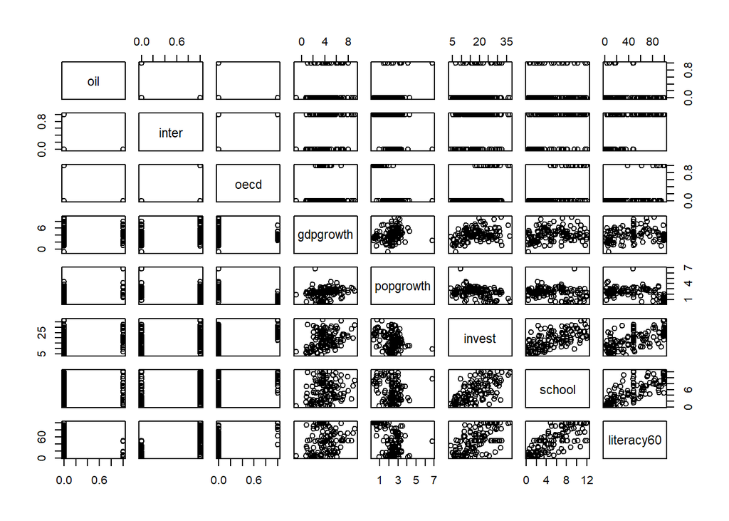

```r
plot(dj1)
```

```r
residuals=model3$residuals
fitval=model3$fitted.values
```

Although two of our variables have a VIF > 10, we are choosing to keep these variables and acknowledge that our model cannot be used to establish a cause-and-effect relationship between our independent variables and gdpgrowth.

#### Testing constant variance

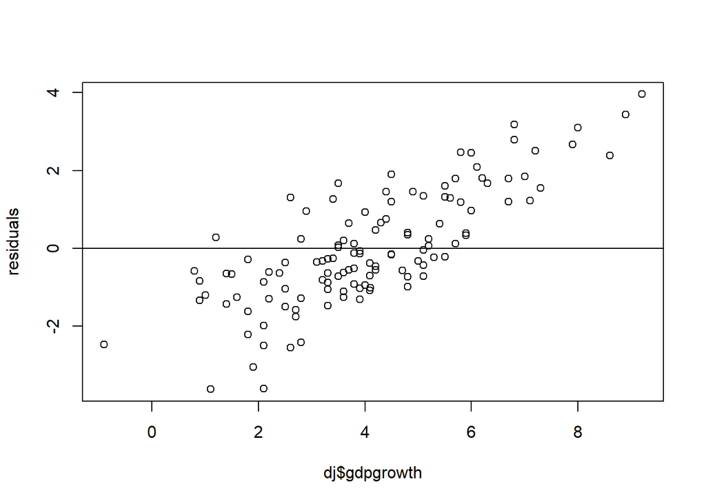

```
## integer(0)
```

```r
plot(dj$gdpgrowth,residuals)+abline(h=0)
```

Since the data points show a pattern of positive correlation, we suspect that the assumption of constant variance is violated. To confirm this, we will conduct a formal ncv test.

$H_0:$ errors have constant variance

$H_a:$ errors have non constant variance

```r
ncvTest(model3)
```

```
## Non-constant Variance Score Test
## Variance formula: ~ fitted.values
## Chisquare = 4.018982, Df = 1, p = 0.044991
```

Since p-value = 0.044991 < $\alpha$ = 0.05, we reject the null hypothesis and conclude that errors have non constant variance. To fix this, we will use the natural log transformation on the dependent variable.

#### Log transformation

```r
log_model3=lm(log(gdpgrowth)~invest+popgrowth+inter+oil+school+oil*popgrowth+I(invest^2),data = dj1)
summary(log_model3)
```

```
##
## Call:
## lm(formula = log(gdpgrowth) ~ invest + popgrowth + inter + oil +
##     school + oil * popgrowth + I(invest^2), data = dj1)
##
## Residuals:
##      Min       1Q   Median       3Q      Max
## -1.28262 -0.18599 -0.01607  0.29332  0.82525
##
## Coefficients:
##                 Estimate Std. Error t value Pr(>|t|)
## (Intercept)   -0.5177745  0.2312537  -2.239 0.027133 *
## invest         0.1139176  0.0239813   4.750 6.07e-06 ***
## popgrowth      0.2079831  0.0499823   4.161 6.24e-05 ***
## inter          0.3298147  0.1127297   2.926 0.004162 **
## oil            0.6818305  0.2739016   2.489 0.014268 *
## school        -0.0191433  0.0148817  -1.286 0.200968
## I(invest^2)   -0.0022086  0.0005934  -3.722 0.000311 ***
## popgrowth:oil -0.1792946  0.0961832  -1.864 0.064927 .
## ---
## Signif. codes:  0 '***' 0.001 '**' 0.01 '*' 0.05 '.' 0.1 ' ' 1
##
## Residual standard error: 0.4078 on 112 degrees of freedom
##   (1 observation deleted due to missingness)
## Multiple R-squared:  0.402,  Adjusted R-squared:  0.3647
## F-statistic: 10.76 on 7 and 112 DF,  p-value: 2.604e-10
```

```r
library(MASS)
library(car)

ncvTest(log_model3)
```

```
## Non-constant Variance Score Test
## Variance formula: ~ fitted.values
## Chisquare = 5.867021, Df = 1, p = 0.015427
```

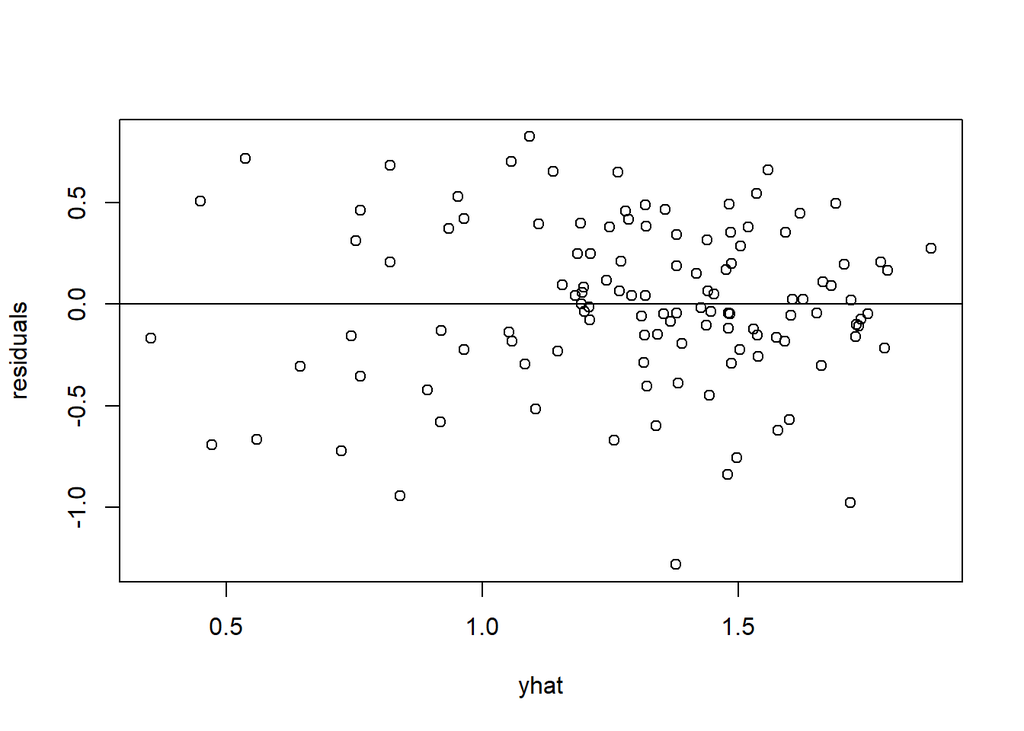

```r
yhat=log_model3$fitted.values
residuals=log_model3$residuals

plot(yhat,residuals)
abline(h=0)
```

#### Influential observations

```r
dist=cooks.distance(model3)
any(dist>1)
```

```
## [1] FALSE
```

We do not have any influential observations in the dataset.

$H_0: B_1=B_2=B_3=B_4=B_5=B_6=B_7=0$

$H_A: B_j\neq0$ for at least one j, where j=1,2,3,4,5,6,7

$\alpha=0.01$

#### Global F test for model adequacy

```r
summary(log_model3)
```

```
##
## Call:
## lm(formula = log(gdpgrowth) ~ invest + popgrowth + inter + oil +
##     school + oil * popgrowth + I(invest^2), data = dj1)
##
## Residuals:
##      Min       1Q   Median       3Q      Max
## -1.28262 -0.18599 -0.01607  0.29332  0.82525
##
## Coefficients:
##                 Estimate Std. Error t value Pr(>|t|)
## (Intercept)   -0.5177745  0.2312537  -2.239 0.027133 *
## invest         0.1139176  0.0239813   4.750 6.07e-06 ***
## popgrowth      0.2079831  0.0499823   4.161 6.24e-05 ***
## inter          0.3298147  0.1127297   2.926 0.004162 **
## oil            0.6818305  0.2739016   2.489 0.014268 *
## school        -0.0191433  0.0148817  -1.286 0.200968
## I(invest^2)   -0.0022086  0.0005934  -3.722 0.000311 ***
## popgrowth:oil -0.1792946  0.0961832  -1.864 0.064927 .
## ---
## Signif. codes:  0 '***' 0.001 '**' 0.01 '*' 0.05 '.' 0.1 ' ' 1
##
## Residual standard error: 0.4078 on 112 degrees of freedom
##   (1 observation deleted due to missingness)
## Multiple R-squared:  0.402,  Adjusted R-squared:  0.3647
## F-statistic: 10.76 on 7 and 112 DF,  p-value: 2.604e-10
```

At 1% significance, we reject the null hypothesis and conclude that the model is statistically useful at predicting the average GDP growth rate between the years 1960 and 1985.

#### Our best chosen model

$\hat{ln(gdpgrowth)}= -0.517745 + 0.1139176* invest + 0.2079831* popgrowth + 0.3298147* inter + 0.6818305* oil - 0.0191433* school - 0.0022086* invest^2 - 0.1792946* popgrowth*oil$

#### Using the model to predict values

```r
gdp=(0.517774473+(3.4*0.113917554)+(1.2*0.207983067)+(0.329814686*0)+(0.681830465*0)+(-0.019143301*3.1) +(-0.002208576*3.4)+(-0.179294552*0))
gdp
```

```
## [1] 1.08782
```